# Evaluation criteria - IST-3 Data

```r
str(data_small)
```

```
## Classes 'data.table' and 'data.frame':   3035 obs. of  6 variables:
##  $ outcome    : Factor w/ 2 levels "0","1": 2 1 1 1 2 2 1 1 2 2 ...
##  $ itt_treat  : Factor w/ 2 levels "rt-PA","Placebo": 1 2 2 1 1 1 1 1 2 2 ...
##  $ nihss      : num  10 18 4 13 6 20 2 9 4 17 ...
##   ..- attr(*, "label")= chr "Total NIH Stroke Score at randomisation"
##  $ randdelay  : num  3.62 1.87 5.08 4.33 1.92 ...
##   ..- attr(*, "label")= chr "Delay (hours) from stroke to randomisation"
##  $ vis_infarct: Factor w/ 2 levels "Yes","No": 2 2 2 1 2 1 2 2 1 1 ...
##  $ age        : num  81 92 75 60 88 84 74 67 75 92 ...
##   ..- attr(*, "label")= chr "Age at randomisation"
##  - attr(*, ".internal.selfref")=<externalptr>
```

```r
summary(data_small)
```

```
##  outcome    itt_treat        nihss         randdelay      vis_infarct
##  0:1088   rt-PA  :1515   Min.   : 0.00   Min.   : 0.100   Yes:1225
##  1:1947   Placebo:1520   1st Qu.: 6.00   1st Qu.: 2.917   No :1810
##                          Median :11.00   Median : 3.867
##                          Mean   :12.11   Mean   : 3.865
##                          3rd Qu.:17.00   3rd Qu.: 4.833
##                          Max.   :37.00   Max.   :24.000
##       age
##  Min.   :31.93
##  1st Qu.:72.00
##  Median :81.00
##  Mean   :77.31
##  3rd Qu.:86.00
##  Max.   :97.85
```

# Resemblance

## Alpha precision, beta recall, authenticity

### m = 5

```r
more_criteria_IST_3_precision_recall_authenticity_m5 <- more_criteria_IST_3_precision_recall_authenticity %>% filter(M == 5)

# Create the table using kable
kable(more_criteria_IST_3_precision_recall_authenticity_m5, format = "markdown", caption = "Results Table")
```

Results Table

| Method | M | AlphaPrecision | BetaRecall | Authenticity |
| --- | --- | --- | --- | --- |
| synthpop | 5 | 0.9001647 | 0.8998353 | 0.5379901 |
| arf | 5 | 0.8873147 | 0.8998353 | 0.5259967 |
| privbayes | 5 | 0.9162438 | 0.8998353 | 0.5487974 |
| ctgan | 5 | 0.8575947 | 0.8998353 | 0.5858979 |
| tvae | 5 | 0.8768369 | 0.8998353 | 0.5270511 |
| tabsyn | 5 | 0.8738715 | 0.8998353 | 0.5525535 |

### m = 10

```r
more_criteria_IST_3_precision_recall_authenticity_m10 <- more_criteria_IST_3_precision_recall_authenticity %>% filter(M == 10)

# Create the table using kable
kable(more_criteria_IST_3_precision_recall_authenticity_m10, format = "markdown", caption = "Results Table")
```

Results Table

| Method | M | AlphaPrecision | BetaRecall | Authenticity |
| --- | --- | --- | --- | --- |
| synthpop | 10 | 0.8989456 | 0.8998353 | 0.5335091 |
| arf | 10 | 0.8861285 | 0.8998353 | 0.5316310 |
| privbayes | 10 | 0.9166063 | 0.8998353 | 0.5472817 |
| ctgan | 10 | 0.8576936 | 0.8998353 | 0.5822735 |
| tvae | 10 | 0.8768040 | 0.8998353 | 0.5208567 |
| tabsyn | 10 | 0.8756507 | 0.8998353 | 0.5472158 |

### m = 50

```r
more_criteria_IST_3_precision_recall_authenticity_m50 <- more_criteria_IST_3_precision_recall_authenticity %>% filter(M == 50)

# Create the table using kable
kable(more_criteria_IST_3_precision_recall_authenticity_m50, format = "markdown", caption = "Results Table")
```

Results Table

| Method | M | AlphaPrecision | BetaRecall | Authenticity |
| --- | --- | --- | --- | --- |
| synthpop | 50 | 0.8958748 | 0.8998353 | 0.5296540 |
| arf | 50 | 0.8844942 | 0.8998353 | 0.5310708 |
| privbayes | 50 | 0.9165008 | 0.8998353 | 0.5457463 |
| ctgan | 50 | 0.8568105 | 0.8998418 | 0.5805140 |
| tvae | 50 | 0.8776936 | 0.8998353 | 0.5249160 |
| tabsyn | 50 | 0.8740428 | 0.8998418 | 0.5504975 |

## Classifier two-sample test (C2ST)

Note: I have specified the limits of the y axis from 0.4 to 1. This is probably not the best option as some boxplots get very thin because of the big range but a consistent range for all plots would be nice.

### KNN

#### Accuracy

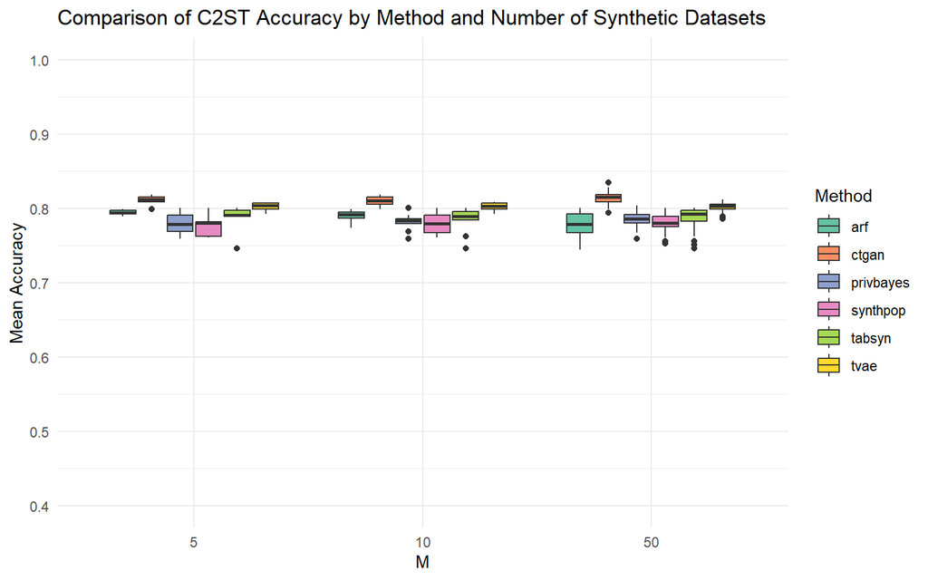

```r
more_criteria_IST_3_c2st_knn <- more_criteria_IST_3_c2st %>% filter(Classifier == "KNN")

# Boxplot erstellen
plot_IST_3_c2st <-ggplot(more_criteria_IST_3_c2st_knn, aes(x = factor(M), y = C2ST_Accuracy, fill = Method)) +
  geom_boxplot() +
  labs(title = "Comparison of C2ST Accuracy by Method and Number of Synthetic Datasets",
       x = "M",
       y = "Mean Accuracy") +
  theme_minimal() +
  scale_fill_brewer(palette = "Set2") +
  scale_y_continuous(limits = c(0.4, 1), breaks = seq(0.4, 1, by = 0.1))
plot_IST_3_c2st
```

Interpretation in general:

- Accuracy ~ 50% -> p-value high (> 0.05) -> $H_0$ is not rejected -> same distributions
- Accuracy ~ 55%-65% -> p-value moderate (= 0.05) -> weak evidence of difference
- Accuracy ~ 65%-80% -> p-value low (< 0.05) -> $H_0$ is rejected -> evidence that distributions are different
- Accuracy ~ 80%-100% -> p-value very low (< 0.001) -> $H_0$ is rejected -> samples are from distinct distributions

#### AUC

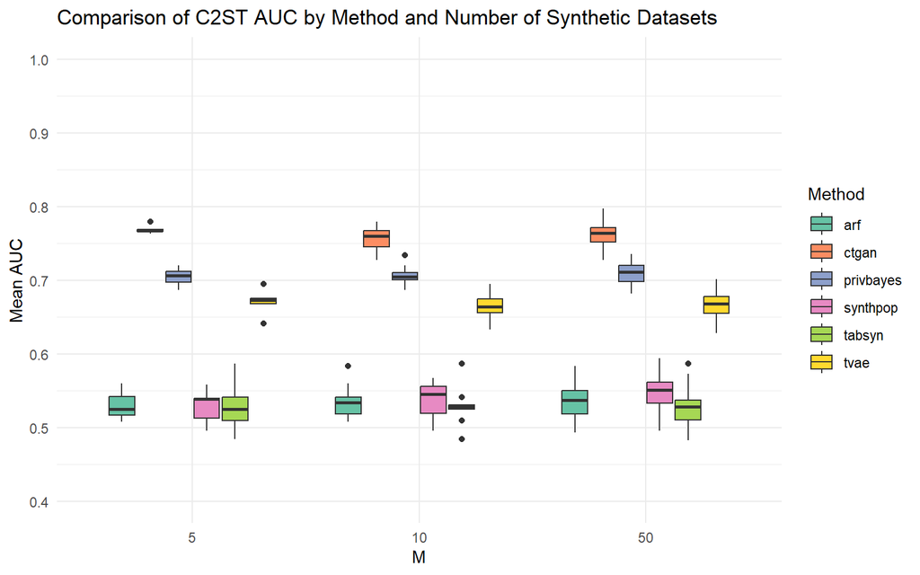

```r
# Boxplot erstellen
plot_IST_3_c2st <-ggplot(more_criteria_IST_3_c2st_knn, aes(x = factor(M), y = AUC, fill = Method)) +
  geom_boxplot() +
  labs(title = "Comparison of C2ST AUC by Method and Number of Synthetic Datasets",
       x = "M",
       y = "Mean AUC") +
  theme_minimal() +
  scale_fill_brewer(palette = "Set2") +
  scale_y_continuous(limits = c(0.4, 1), breaks = seq(0.4, 1, by = 0.1))
plot_IST_3_c2st
```

### RF

#### Accuracy

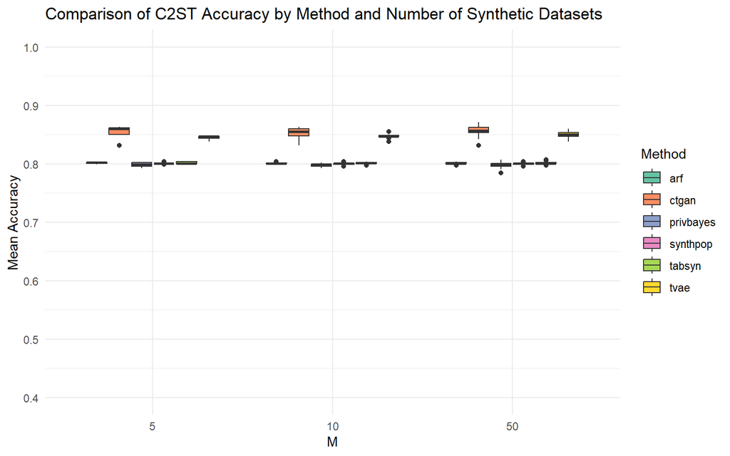

```r
more_criteria_IST_3_c2st_rf <- more_criteria_IST_3_c2st %>% filter(Classifier == "RF")

# Boxplot erstellen
plot_IST_3_c2st <- ggplot(more_criteria_IST_3_c2st_rf, aes(x = factor(M), y = C2ST_Accuracy, fill = Method)) +
  geom_boxplot() +
  labs(title = "Comparison of C2ST Accuracy by Method and Number of Synthetic Datasets",
       x = "M",
       y = "Mean Accuracy") +
  theme_minimal() +
  scale_fill_brewer(palette = "Set2") +
  scale_y_continuous(limits = c(0.4, 1), breaks = seq(0.4, 1, by = 0.1))
plot_IST_3_c2st
```

#### AUC

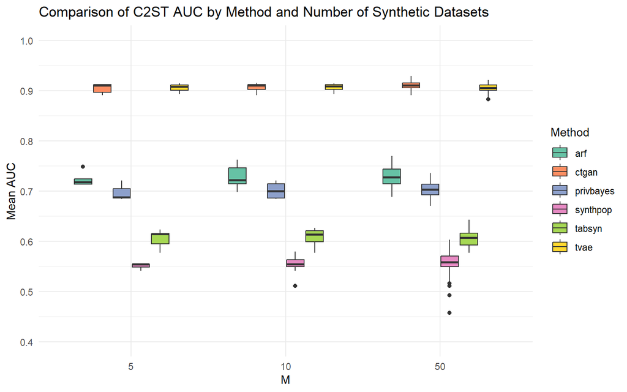

```r
# Boxplot erstellen
plot_IST_3_c2st <-ggplot(more_criteria_IST_3_c2st_rf, aes(x = factor(M), y = AUC, fill = Method)) +
  geom_boxplot() +
  labs(title = "Comparison of C2ST AUC by Method and Number of Synthetic Datasets",
       x = "M",
       y = "Mean AUC") +
  theme_minimal() +
  scale_fill_brewer(palette = "Set2") +
  scale_y_continuous(limits = c(0.4, 1), breaks = seq(0.4, 1, by = 0.1))
plot_IST_3_c2st
```

### NN

#### Accuracy

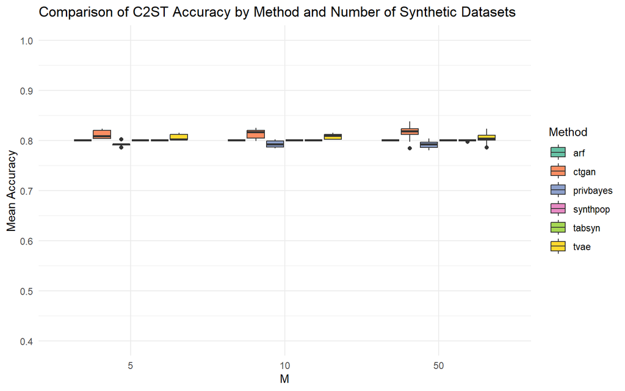

```r
more_criteria_IST_3_c2st_nn <- more_criteria_IST_3_c2st %>% filter(Classifier == "NN")

# Boxplot erstellen
plot_IST_3_c2st <-ggplot(more_criteria_IST_3_c2st_nn, aes(x = factor(M), y = C2ST_Accuracy, fill = Method)) +
  geom_boxplot() +
  labs(title = "Comparison of C2ST Accuracy by Method and Number of Synthetic Datasets",
       x = "M",
       y = "Mean Accuracy") +
  theme_minimal() +
  scale_fill_brewer(palette = "Set2") +
  scale_y_continuous(limits = c(0.4, 1), breaks = seq(0.4, 1, by = 0.1))
plot_IST_3_c2st
```

#### AUC

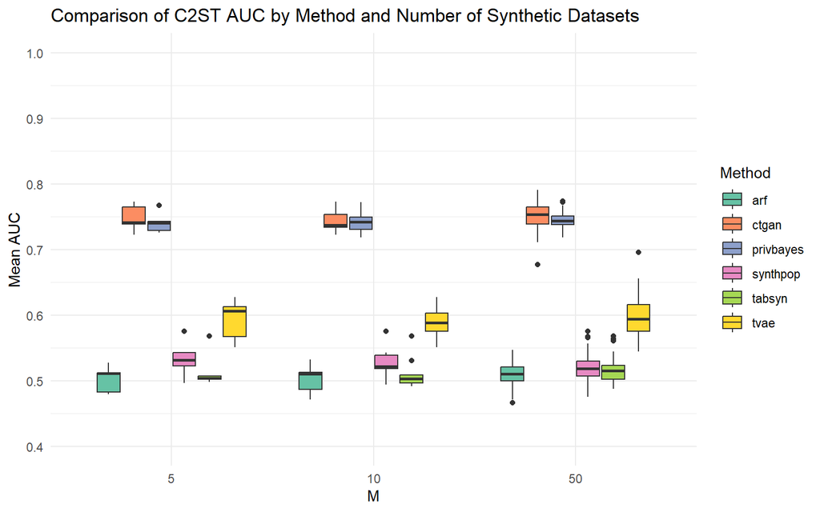

```r
# Boxplot erstellen
plot_IST_3_c2st <-ggplot(more_criteria_IST_3_c2st_nn, aes(x = factor(M), y = AUC, fill = Method)) +
  geom_boxplot() +
  labs(title = "Comparison of C2ST AUC by Method and Number of Synthetic Datasets",
       x = "M",
       y = "Mean AUC") +
  theme_minimal() +
  scale_fill_brewer(palette = "Set2") +
  scale_y_continuous(limits = c(0.4, 1), breaks = seq(0.4, 1, by = 0.1))
plot_IST_3_c2st
```

# Utility

## Statistical Utility

Note: The colors still have to be changed to be consistent with the other plots.

[figure not shown]

## ML Utility

Es wird beurteilt, wie gut Modelle, die mit synthetischen Daten trainiert wurden, auf echten Daten performen. Bei Klassifikationsaufgaben werden Accuracy und/oder F1-Score betrachtet, während bei Regressionsaufgaben der R²-Wert (Bestimmtheitsmaß) betrachtet wird.

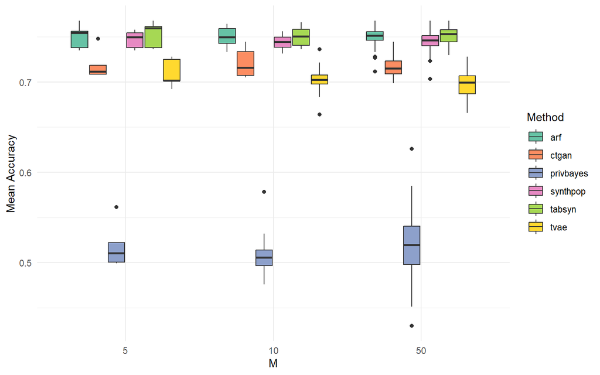

```r
# Boxplot erstellen - R^2
plot_IST_3_ml_utility_r_squared <- ggplot(more_criteria_IST_3_ml_utility, aes(x = factor(M), y = Accuracy, fill = Method)) +
  geom_boxplot() +
  labs(x = "M",
       y = "Mean Accuracy") +
  theme_minimal() +
  scale_fill_brewer(palette = "Set2")
plot_IST_3_ml_utility_r_squared
```

# Privacy

## Share of identical records (SIR)

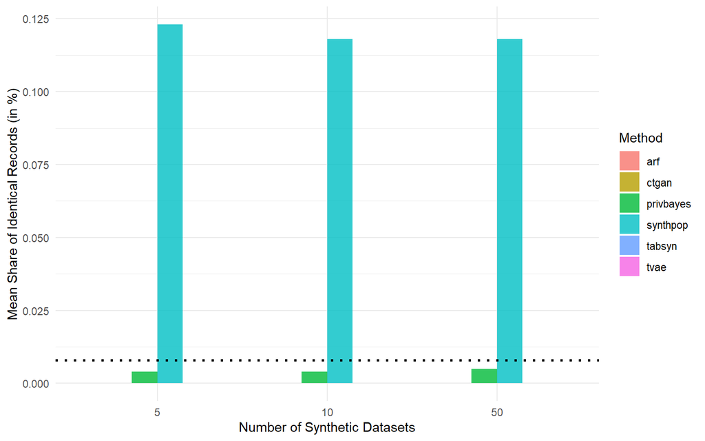

```r
# Die Farben müssen noch angepasst werden, da ja noch TABSYN dazugekommen ist

plot_IST_3_sir <- ggplot(more_criteria_IST_3_mean_sir, aes(x = factor(M), y = Mean_IMS_Train_Syn, fill = Method)) +
  geom_bar(stat = "identity", position = "dodge", alpha = 0.8) +
  geom_hline(yintercept = mean(more_criteria_IST_3_mean_sir$Mean_IMS_Train_Test),
             linetype = "dotted", color = "black", size = 1) +
  theme_minimal() +
  labs(
    x = "Number of Synthetic Datasets",
    y = "Mean Share of Identical Records (in %)"
  ) +
  #scale_fill_manual(values = c("#66C2A5", "#FC8D62", "#8DA0CB", "#E78AC3", "#a6d854")) + # Pastellfarben
  #scale_fill_manual(values = c("#E69F00", "#56B4E9", "#009E73", "#D55E00")) + # Kontrastreiche Palette
  theme(legend.position = "right")
plot_IST_3_sir
```

## Distance to closest records (DCR)

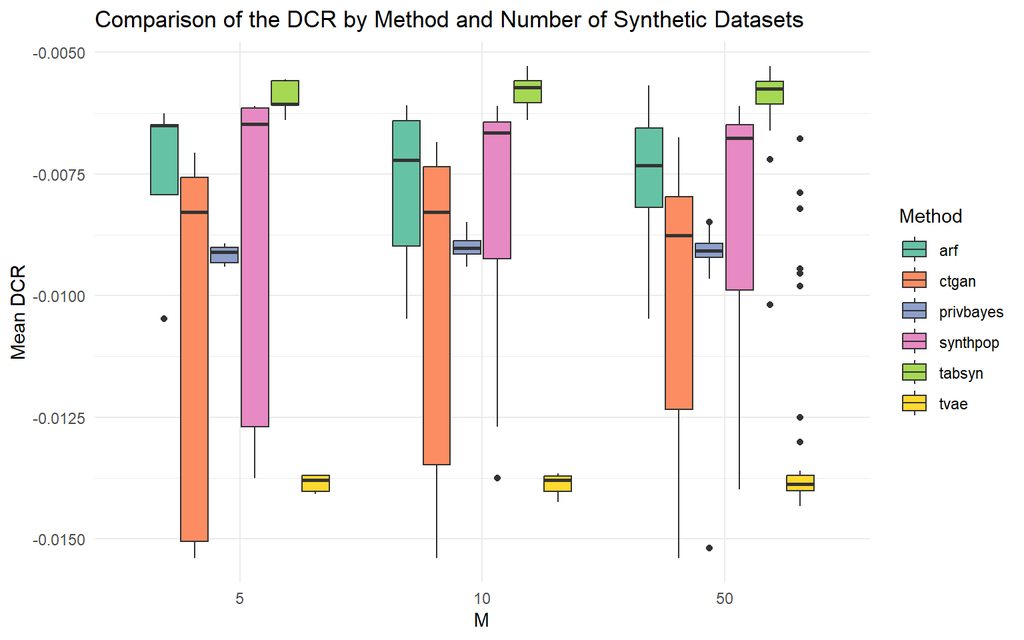

```r
# Boxplot erstellen
plot_IST_3_dcr <-ggplot(more_criteria_IST_3_dcr, aes(x = factor(M), y = DCR, fill = Method)) +
  geom_boxplot() +
  labs(title = "Comparison of the DCR by Method and Number of Synthetic Datasets",
       x = "M",
       y = "Mean DCR") +
  theme_minimal() +
  scale_fill_brewer(palette = "Set2")
plot_IST_3_dcr
```

In general: The distances between synthetic data and training data should not be systematically smaller than between training and holdout data.

Interpretation:

- The DCR values are small negative numbers.
- Since DCR is calculated as the difference between the minimum distances to the training and holdout sets, a negative value suggests that, on average, synthetic records are slightly closer to the holdout set than to the training set.
- This could indicate that the synthetic data captures the distribution well and does not overfit to the training data.
- More negative values may indicate potential overfitting to the training data.
- -> When the difference is negative, then the distances between synthetic data and training data are not systematically smaller than between training and holdout data
- -> good

## Nearest-neighbor distance ratio (NNDR)

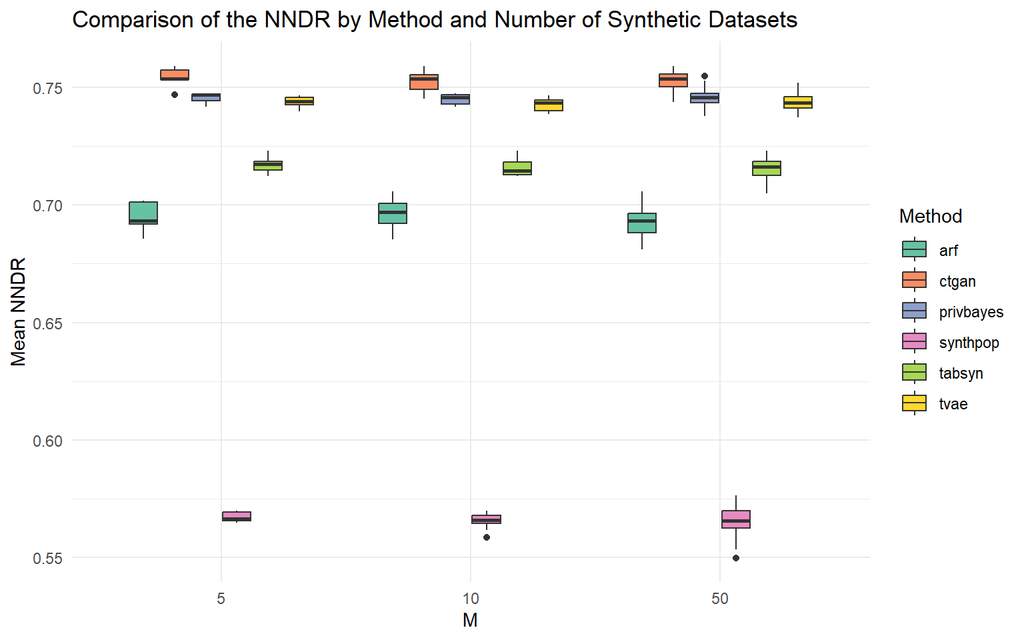

```r
# Boxplot erstellen
plot_IST_3_nndr <- ggplot(more_criteria_IST_3_nndr, aes(x = factor(M), y = Mean_NNDR_Filtered, fill = Method)) +
  geom_boxplot() +
  labs(title = "Comparison of the NNDR by Method and Number of Synthetic Datasets",
       x = "M",
       y = "Mean NNDR") +
  theme_minimal() +
  scale_fill_brewer(palette = "Set2")
plot_IST_3_nndr
```

Interpretation in general:

- NNDR close to 1: The nearest and second-nearest neighbors are almost equally distant, meaning the synthetic data does not strongly resemble a specific real point. Suggests good privacy.
- NNDR close to 0: The nearest neighbor is much closer than the second-nearest, meaning the synthetic data point is highly similar to one real data point. This suggests higher privacy risk.
- Moderate NNDR: More balanced privacy and resemblance